# Comparitive Analysis of Effectiveness of Three Systolic Blood Pressure Medications

Reece Fannon

14 September 2024

# **1 Introduction**

This report presents the results of an analysis comparing the effectiveness of three different drugs in reducing systolic blood pressure (SBP). SBP is a critical measure of cardiovascular health, representing the force exerted by the blood against the artery walls when the heart beats [^1]. Elevated SBP is a known risk factor for serious conditions such as heart disease and stroke, making its reduction a key target in medical treatment.

An experiment was conducted to attempt to determine what an effective treatment is for high SBP. In this report, we will address the following:

- Assess if the three drugs are equally effective in lowering mean SBP.
- Identify the most effective drug
- Evaluate the validity that the subject were indeed randomly assigned to drug treatments.

By conducting this analysis, we aim to provide clear insights into the comparative effectiveness of the drugs and ensure that the experiment was conducted in a fair and ethical way. These findings will help inform future decisions on the optimal treatment for reducing SBP.

# **2 Methods**

## **2.1 Data**

We analyze the data compiled by the client during their experiment. Twelve individuals had their initial SBP in millimeters of mercury (mmHg) measured and then four were randomly assigned to each of the three treatment groups. After administration of the respective drug for the duration of the experiment (which is unspecified) the SBPs of each subject were measured again.

The data contains only the four variables: the subject, their assigned treatment and their SBP before and after the experiment. No other information about subjects or how the experiment was conducted are available.

## **2.2 Analysis**

In this analysis, we will primarily be using one-way Analysis of Variance (ANOVA) to assess the differences in mean response (absolute and relative reduction in SBP) given the drug the subject was treated with. The usual additive model is given in the form

$$\begin{equation}
\tag{1}
Y_{ij} = \mu + \tau_j + \epsilon_{ij}
\end{equation}$$

where

- $Y_{ij}$ is the response of the $i^{th}$ subject from the $j^{th}$ treatment group ($Y_{ij} = |\delta_{ij}|$ or $Y_{ij} = |\delta\%_{ij}|$).
- $\mu$ is the overall mean response from all subjects.
- $\tau_j$ is the added (or differential) effect of the $j^{th}$ treatment on $\mu$.
- $\epsilon_{ij}$ is the error on the response for the $i^{th}$ subject from the $j^{th}$ treatment group.

Additionally, we have that

$$\sum_{j=1}^m \tau_j = 0, \epsilon_{ij} \sim N(0, \sigma^2)$$

For convenience, we will work with the equivalent linear regression form of the ANOVA model:

$$\begin{equation}
\tag{2}
Y_{ij} = \beta_0 + \beta_1X_1 + \beta_2X_2 + \epsilon_{ij}
\end{equation}$$

where

- $X_1 = \begin{cases} 1, Moexipril \\ 0, otherwise \end{cases}$ indicates if subject $i$ belongs to the Moexipril group.
- $X_2 = \begin{cases} 1, Ramipril \\ 0, otherwise \end{cases}$ indicates if the subject $i$ belongs to the Ramipril group.
- $\beta_0$ is the true mean response for people taking Lisinopril group.
- $\beta_1$ is the true mean difference in response of people taking Moexipril from those taking Lisinopril.
- $\beta_2$ is the true mean difference in response of people taking Ramipril from those taking Lisinopril.

The assumptions of the ANOVA model are as follows:

- **Independence** The observations should be independent of each other.
- **Normality** The distribution of the residuals (or responses) are normally distributed.
- **Homoscedasticity** The variance within each treatment group is the same.
- **Randomization** The experiment should follow a completely randomized design. Each subject was randomly assigned to a treatment group.

## **2.3 Randomization**

To assess whether the twelve subjects were randomly assigned to treatment groups, we should consider the distributional differences between the characteristics of the subject *before* the experiment began. The researchers have no way of knowing how the subjects will react to the drugs, so the ending blood pressure can be ignored. The only available prior information is the starting blood pressure. It is presumable that the researchers probably had other information about each subject before the experiment began, such as their age, weight, sex, etc. But in the provided data we only have their starting blood pressures to work with. If we had the other contextual information about each subject, then more analysis could be done.

We can also perform a test to see if the subjects were randomly assigned. A randomization test (or permutation test) is a non-parametric test used to test the null hypothesis that there is no difference between groups or treatments. It works by comparing an observed test statistic (such as the F-statistic) to a distribution of test statistics generated by randomly reassigning or “permuting” the group labels. The idea is to simulate what the data would look like under the null hypothesis, where any observed differences are due to chance alone. In each permutation, the group labels are shuffled, but the actual data (the starting blood pressures) stay the same. After repeated random permutations, the observed test statistic of the actual data and true labels is compared to the distribution of permuted test statistics with the swapped labels. The proportion of permuted test statistics that are as extreme as or more extreme than the observed one gives the p-value, which reflects the likelihood of observing such a result if the null hypothesis were true. The non-parametric nature of the test makes it robust to assumption violations and small sample sizes. For details on the insight and performance of a randomization test, see [^2].

## **2.4 Software**

For our analysis, we will be utilizing the statistical software *R* [^3] to conduct all data processing and statistical tests. Specifically, we will employ several R packages to enhance our workflow and output. The *tidyverse* [^4] package will be used for data manipulation and visualization, while *MASS* [^5] will assist with statistical modeling and methods. We will also leverage *gridExtra* [^6] to arrange multiple plots, *kableExtra* [^7] to produce well-formatted tables, and *captioner* [^8] to manage figure and table captions. These tools collectively ensure a comprehensive and efficient analysis process.

# **3 Results**

## **3.1 EDA**

$$\begin{equation}
\tag{3}
|\delta| = |Y_{before} - Y_{after}|
\end{equation}$$

$$\begin{equation}
\tag{4}
|\delta\%| = 100*\frac{|\delta|}{Y_{before}} = 100*|\frac{Y_{before} -
Y_{after}}{Y_{before}}|
\end{equation}$$

Table: Mean (SD) metrics for each treatment group

| Drug | Before | After | Change | % Change |
| --- | --- | --- | --- | --- |
| Lisinopril | 170.25 (12.39) | 131.5 (9.68) | 38.75 (14.95) | 0.22 (0.07) |
| Moexipril | 172.75 (13.4) | 128.25 (4.92) | 44.5 (8.81) | 0.26 (0.03) |
| Ramipril | 179.75 (13.28) | 147.75 (9.29) | 32 (6.38) | 0.18 (0.03) |

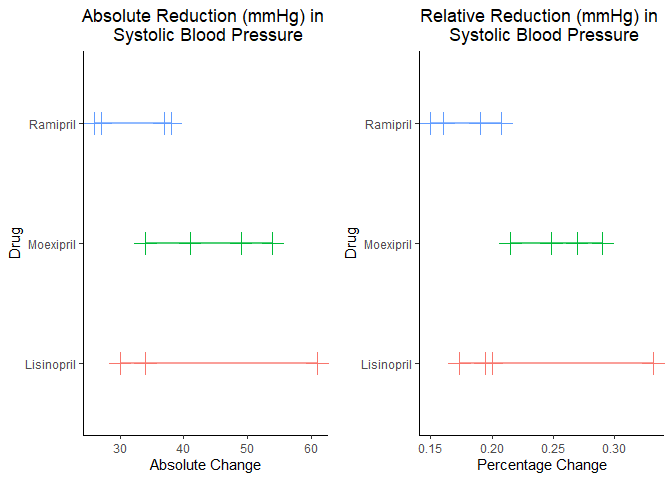

Figure 2: some more graphs

Every subject showed a considerable drop in blood pressure, giving evidence at the very least that each drug appears to be effective in treating hypertension. However, we cannot make out which drug could superior. One subject in the Lisinopril group showed a significant absolute and relative reduction in systolic blood pressure compared to all others in the study. In fact, this individual responded very well to the treatment even compared to their treatment peers. One wonders if this individual would have shown an even larger reduction in the Moexipril group, which does appear to larger percent reductions in blood pressure than the Ramipirl group. Additionally, all four subjects of the Moexipril group showed larger percentage reductions than the lower three subject of the Lisinopril group.

## **3.2 Models**

With three treatment groups to compare, and when considering the mean absolute or percentage reduction in systolic blood pressure for each group, it is natural to want to continue with the analysis of variance (ANOVA). However, we also consider some alternative methods that could be more accurate than the one-way ANOVA. In this model, we fit the equation

$$\begin{equation}
\tag{5}
|\delta|_{ij} = \beta_0 + \beta_1X_1 + \beta_2X_2 + \epsilon_{ij}
\end{equation}$$

or similarly,

$$\begin{equation}
\tag{6}
|\delta\%|_{ij} = \beta_0 + \beta_1X_1 + \beta_2X_2 + \epsilon_{ij}
\end{equation}$$

where $|\delta|_{ij}$ is the absolute reduction in SBP for the $i^{th}$ subject in the $j^{th}$ treatment group and $|\delta\%|_{ij}$ is the relative or percentage reduction in SBP given the starting blood pressure of the $i^{th}$ subject in the $j^{th}$ treatment group.

However, both $(5)$ and $(6)$ suffer from a similar shortcoming. They assume that the starting SBP has a fixed or constant effect on the post experiment SBP. To remedy this, we fit a slight variation of the model

$$\begin{equation}
\tag{7}
Y_{after}^{(ij)} = \beta_0 + \beta_1X_1 + \beta_2X_2 +
\beta_3Y_{before}^{(ij)} + \epsilon_{ij}
\end{equation}$$

where

- where $Y_{after}^{(ij)}$ is the systolic blood pressure of the $i^{th}$ subject in the $j^{th}$ treatment group *after* having taken the $j^{th}$ treatment for the period of the experiment.
- $Y_{before}^{(ij)}$ is the systolic blood pressure of the $i^{th}$ subject in the $j^{th}$ treatment group *before* the beginning of the experiment.
- $\beta_3$ is the true mean change in $Y_{after}^{(ij)}$ given a unit increase in $Y_{before}^{(ij)}$

In this variation of the ANOVA model, we use the starting blood pressure as a *covariate* to the ending blood pressure. We are effectively saying that the starting blood pressure will effect someones ending blood pressure. This is called the Analysis of Covariance (ANCOVA) model. For details on all of these models, see [^9].

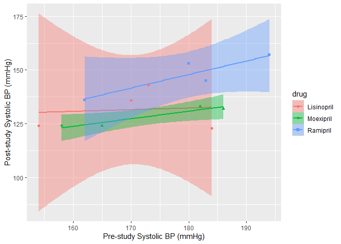

Linear Model Summary

|  | Estimate | Std. Error | t-value | p-value |
| --- | --- | --- | --- | --- |
| Intercept | 69.393 | 31.349 | 2.214 | 0.058 |
| Before | 0.365 | 0.183 | 1.994 | 0.081 |
| Moexipril | -4.162 | 5.077 | -0.82 | 0.436 |
| Ramipril | 12.784 | 5.347 | 2.391 | 0.044 |
| R squared | 0.621 |  |  |  |
| F-Statistic | 7.017 | 3 | 8 | 0.012 |

## **3.3 Randomization**

If the subjects were randomly assigned, we should expect to see a relatively uniform (non informative) distributions of the the starting blood pressures. This is precisely what we see in figure below, though the Ramipril and Lisinopril groups appear to have some higher and lower pressures, respectively. However, with only four subjects per treatment group, the eyeball test shows nothing suspicious here.

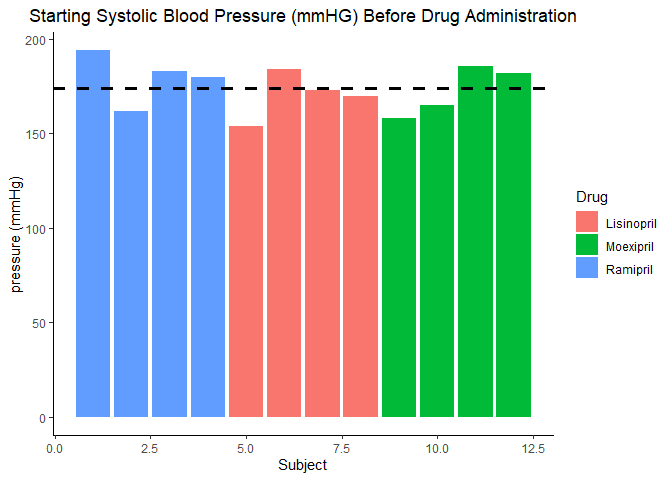

Based on the results of our permutation test (see figure below), it does not appear that there is any reason to suspect any malfeasance in the assignment of subjects to treatment groups. The observed assignment appears to be a perfectly likely assingment of the treatments.

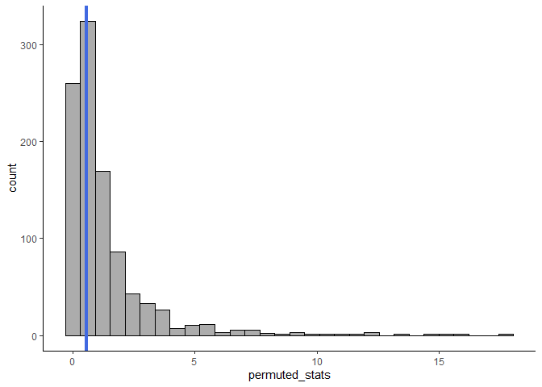

| Observed F Value | Permutation p-value |
| --- | --- |
| 0.5712416 | 0.57 |

# **4 Conclusion**

## **4.1 Findings**

Based on our analysis, Moexipril appears to be the most effective drug in reducing mean systolic blood pressure, with an estimated reduction of approximately 4.2 mmHg more than Lisinopril and over 16 mmHg more than Ramipril. Regarding the randomization of subjects, we find no evidence of foul play in the assignment of treatments. While we cannot definitively confirm the legitimacy of randomization without consulting the researchers, there is no reason to suspect any irregularities.

## **4.2 limitations**

However, we strongly caution against drawing any firm conclusions or taking immediate action based on these results. The study’s small sample size of only 12 subjects, with just four replicates per treatment group, limits the reliability of the findings and makes the results particularly vulnerable to the influence of outliers and violation of model assumptions. Additionally, because we lack information about other subject characteristics beyond their systolic blood pressures, various external factors could be impacting the outcomes, further reducing the certainty of our conclusions. We are also ignorant to the specifics of how the experiment was conducted, such as the duration of the experiment. It is possible that some drugs are more effective in the short term, but lose their effectiveness in the long term, and vice versa. The only suggestion we can confidently make here is that there appears to be reason for further research with a larger and more detailed dataset.

# **References**

[^1]: National Heart, Lung, and Blood Institute. (n.d.) *High blood pressure*. U.S. Department of Health and Human Services. https://www.nhlbi.nih.gov/health/high-blood-pressure.
[^2]: Sauro, J. (2020, August 25). *How to conduct a randomization test*. MeasuringU. https://measuringu.com/randomization-test/
[^3]: R Core Team (2024). *R: A Language and Environment for Statistical Computing*. R Foundation for Statistical Computing, Vienna, Austria. https://www.R-project.org/.
[^4]: Wickham H, Averick M, Bryan J, Chang W, McGowan LD, François R, Grolemund G, Hayes A, Henry L, Hester J, Kuhn M, Pedersen TL, Miller E, Bache SM, Müller K, Ooms J, Robinson D, Seidel DP, Spinu V, Takahashi K, Vaughan D, Wilke C, Woo K, Yutani H (2019). “Welcome to the tidyverse.” *Journal of Open Source Software*, *4*(43), 1686. doi:10.21105/joss.01686 https://doi.org/10.21105/joss.01686.
[^5]: Venables, W. N. & Ripley, B. D. (2002) Modern Applied Statistics with S. Fourth Edition. Springer, New York. ISBN 0-387-95457-0.
[^6]: Auguie B (2017). *gridExtra: Miscellaneous Functions for “Grid” Graphics*. R package version 2.3, https://CRAN.R-project.org/package=gridExtra.
[^7]: Zhu H (2024). *kableExtra: Construct Complex Table with ‘kable’ and Pipe Syntax*. R package version 1.4.0, https://CRAN.R-project.org/package=kableExtra.
[^8]: Alathea L (2015). *captioner: Numbers Figures and Creates Simple Captions*. R package version 2.2.3, https://CRAN.R-project.org/package=captioner.
[^9]: Montgomery, D. C. (2013). *Design and analysis of experiments* (8th ed.). John Wiley & Sons.